# Working with tables in R (tidyverse)

*INRAe-IFB-INSERM Bioinformatics School 2026*

- Elodie Girard - Institut Curie

**Goal of this session**

Learn the few tidyverse tools needed to read, reshape, filter, summarise and plot a table. The same verbs will be used in the next notebook to analyse a VCF file.

| Step | Package | Main verbs |
| --- | --- | --- |
| Reshape | `tidyr` | `unite`, `separate`, `pivot_longer`, `pivot_wider` |
| Transform | `dplyr` | `filter`, `select`, `mutate`, `group_by`, `summarise`, `*_join` |
| Text | `stringr` | `str_detect`, `str_length`, `str_extract` |
| Plot | `ggplot2` | `geom_point`, `geom_line`, `geom_histogram`, `geom_density` |

Load the packages once at the top of the notebook (install them first if needed with `install.packages("tidyverse")`).

```r
suppressPackageStartupMessages({
  library(tibble)
  library(tidyr)
  library(dplyr)
  library(stringr)
  library(ggplot2)
})
```

## I - Reminder: R objects

**Variable**: stores one numeric value or one character string.

```r
string <- "hello world"
value  <- 10
string
value
```

'hello world'

10

**Vector**: stores a series of values of the **same type** (numeric, character, logical...).

```r
vect <- c(1, 2, 11, 12)
vect
vect[2]       # second element
vect[vect > 5]  # logical indexing
```

1. 1

2. 2

3. 11

4. 12

2

1. 11

2. 12

**Matrix**: a 2D table of values of the **same type**.

```r
mat <- matrix(c(1, 2, 11, 12), nrow = 2, ncol = 2, byrow = TRUE)
mat
```

A matrix: 2 × 2 of type dbl

| 1 | 2 |
| --- | --- |
| 11 | 12 |

**data.frame**: a 2D table whose columns can have **different types**.

```r
df <- data.frame(num = c(1, 11), chr = c("x", "y"))
df
str(df)
```

A data.frame: 2 × 2

| num <dbl> | chr <chr> |
| --- | --- |
| 1 | x |
| 11 | y |

```
'data.frame':	2 obs. of  2 variables:
 $ num: num  1 11
 $ chr: chr  "x" "y"
```

**List**: stores objects of **different nature** (here a vector, a matrix and a data.frame).

```r
lst <- list(vector = vect, matrix = mat, dataframe = df)
str(lst)
lst$dataframe   # or lst[["dataframe"]]
```

```
List of 3
 $ vector   : num [1:4] 1 2 11 12
 $ matrix   : num [1:2, 1:2] 1 11 2 12
 $ dataframe:'data.frame':	2 obs. of  2 variables:
  ..$ num: num [1:2] 1 11
  ..$ chr: chr [1:2] "x" "y"
```

A data.frame: 2 × 2

| num <dbl> | chr <chr> |
| --- | --- |
| 1 | x |
| 11 | y |

⚠️ **Warning**  
Do not name a variable `list`, `c`, `df` or `data`: it hides an existing R function. We use `lst` here.

**S3 / S4 objects (object-oriented programming)**: store structured data with named **slots**.

This is what `vcfR` does: a VCF is stored in an S4 object with the slots `@meta`, `@fix` and `@gt`.

```r
# A minimal S4 class describing a variant
setClass("Variant", representation(chrom = "character", pos = "numeric"))
v <- new("Variant", chrom = "NC_037329.1", pos = 90572569)

isS4(v)
slotNames(v)
v@pos          # access a slot with @
```

TRUE

1. 'chrom'

2. 'pos'

90572569

## II - The tidyverse and tidy data

tidyverse.org: a collection of R packages that share the same design and the same data structures.

**Tidy data** is a way to organise tabular data in a consistent structure across packages:

1. each **variable** is a column,
2. each **observation** is a row,
3. each **value** is a cell.

**Tibbles** are the table format of the `tibble` package. They inherit from the `data.frame` class but have improved behaviour: compact printing with column types, no silent conversion of strings to factors, no partial column matching.

```r
tb <- tibble(
  name  = c("dupont_lepetit", "jean_legrand", "toto_tutu"),
  month = c("09", "11", "04"),
  year  = c(1945, 2000, 1820)
)
tb
class(tb)
```

A tibble: 3 × 3

| name <chr> | month <chr> | year <dbl> |
| --- | --- | --- |
| dupont_lepetit | 09 | 1945 |
| jean_legrand | 11 | 2000 |
| toto_tutu | 04 | 1820 |

1. 'tbl_df'

2. 'tbl'

3. 'data.frame'

### Printing a tibble: compact, with the type of each column

```r
print(as_tibble(iris), n = 5)   # a tibble never floods the console: 10 rows by default, here 5
```

```
# A tibble: 150 × 5
  Sepal.Length Sepal.Width Petal.Length Petal.Width Species
         <dbl>       <dbl>        <dbl>       <dbl> <fct>
1          5.1         3.5          1.4         0.2 setosa
2          4.9         3            1.4         0.2 setosa
3          4.7         3.2          1.3         0.2 setosa
4          4.6         3.1          1.5         0.2 setosa
5          5           3.6          1.4         0.2 setosa
# ℹ 145 more rows
```

## III - Data tidying with `tidyr`

Cheat sheet: tidyr.pdf

```
install.packages("tidyr")
library(tidyr)
```

### `unite()`: merge several columns into one

`unite(data, col, ..., sep = "_", remove = TRUE)`

```r
tb
```

A tibble: 3 × 3

| name <chr> | month <chr> | year <dbl> |
| --- | --- | --- |
| dupont_lepetit | 09 | 1945 |
| jean_legrand | 11 | 2000 |
| toto_tutu | 04 | 1820 |

```r
unite(tb, col = "birth", month, year, sep = "/", remove = TRUE)
```

A tibble: 3 × 2

| name <chr> | birth <chr> |
| --- | --- |
| dupont_lepetit | 09/1945 |
| jean_legrand | 11/2000 |
| toto_tutu | 04/1820 |

### `separate()`: split one column into several

`separate(data, col, into, sep, remove = TRUE)`

```r
separate(tb, col = "name", into = c("Fname", "Lname"), sep = "_", remove = TRUE)
```

A tibble: 3 × 4

| Fname <chr> | Lname <chr> | month <chr> | year <dbl> |
| --- | --- | --- | --- |
| dupont | lepetit | 09 | 1945 |
| jean | legrand | 11 | 2000 |
| toto | tutu | 04 | 1820 |

### `separate_wider_delim()`: the newer alternative

ℹ️ **Note**  
Since `tidyr` 1.3.0, `separate()` is superseded by `separate_wider_delim()` (stricter: it reports rows that do not split as expected). `separate()` still works and is widely used, including in the next notebook.

```r
separate_wider_delim(tb, cols = name, delim = "_", names = c("Fname", "Lname"))
```

A tibble: 3 × 4

| Fname <chr> | Lname <chr> | month <chr> | year <dbl> |
| --- | --- | --- | --- |
| dupont | lepetit | 09 | 1945 |
| jean | legrand | 11 | 2000 |
| toto | tutu | 04 | 1820 |

### Chaining with the pipe

The pipe passes the result of the left side as the **first argument** of the function on the right side. This notebook uses the magrittr pipe `%>%` (exported by `dplyr` and `tidyr`). Since R 4.1 a native pipe `|>` is also available and works the same way in these examples.

```r
# Step by step
tb.u <- unite(tb, col = "birth", month, year, sep = "/")
separate(tb.u, col = "name", into = c("Fname", "Lname"), sep = "_")
```

A tibble: 3 × 3

| Fname <chr> | Lname <chr> | birth <chr> |
| --- | --- | --- |
| dupont | lepetit | 09/1945 |
| jean | legrand | 11/2000 |
| toto | tutu | 04/1820 |

### Chained: same result, no intermediate object

```r
# Chained: same result, no intermediate object
tb %>%
  unite(col = "birth", month, year, sep = "/") %>%
  separate(col = "name", into = c("Fname", "Lname"), sep = "_")
```

A tibble: 3 × 3

| Fname <chr> | Lname <chr> | birth <chr> |
| --- | --- | --- |
| dupont | lepetit | 09/1945 |
| jean | legrand | 11/2000 |
| toto | tutu | 04/1820 |

### `pivot_longer()` / `pivot_wider()`: long and wide formats

**long** = one row per (name, key) pair, **wide** = one column per key. They replace the older `gather()` / `spread()`.

```r
long <- pivot_longer(tb, cols = c(month, year), names_to = "key", values_to = "value",
                     values_transform = list(value = as.character))
long
```

A tibble: 6 × 3

| name <chr> | key <chr> | value <chr> |
| --- | --- | --- |
| dupont_lepetit | month | 09 |
| dupont_lepetit | year | 1945 |
| jean_legrand | month | 11 |
| jean_legrand | year | 2000 |
| toto_tutu | month | 04 |
| toto_tutu | year | 1820 |

ℹ️ **Note**  
`month` is a character column and `year` a numeric column: both must have the same type to be stacked in one `value` column, hence `values_transform`.

### `pivot_wider()`: back to the wide format

```r
pivot_wider(long, names_from = key, values_from = value)
```

A tibble: 3 × 3

| name <chr> | month <chr> | year <chr> |
| --- | --- | --- |
| dupont_lepetit | 09 | 1945 |
| jean_legrand | 11 | 2000 |
| toto_tutu | 04 | 1820 |

## IV - Data transformation with `dplyr`

Cheat sheet: data-transformation.pdf

```
install.packages("dplyr")
library(dplyr)
```

### `filter()`: pick **rows** based on their values

```r
d <- tibble(X = 1:4, Y = c(0, 4, 10, 1), Z = c("no", "yes", "yes", "yes"))
d
```

A tibble: 4 × 3

| X <int> | Y <dbl> | Z <chr> |
| --- | --- | --- |
| 1 | 0 | no |
| 2 | 4 | yes |
| 3 | 10 | yes |
| 4 | 1 | yes |

```r
filter(d, Y > 2, Z == "yes")   # conditions separated by a comma are combined with AND
```

A tibble: 2 × 3

| X <int> | Y <dbl> | Z <chr> |
| --- | --- | --- |
| 2 | 4 | yes |
| 3 | 10 | yes |

### `filter()`: more ways to combine conditions

💡 **Tip**  
Use `|` for OR, `%in%` to test membership in a vector, `!` to negate, and `is.na()` to test for missing values.

```r
filter(d, X == 1 | Y > 5)   # OR
```

A tibble: 2 × 3

| X <int> | Y <dbl> | Z <chr> |
| --- | --- | --- |
| 1 | 0 | no |
| 3 | 10 | yes |

### `filter()`: membership and negation

```r
filter(d, Z %in% c("no", "maybe"))
filter(d, !is.na(Y), !(Z == "yes"))
```

A tibble: 1 × 3

| X <int> | Y <dbl> | Z <chr> |
| --- | --- | --- |
| 1 | 0 | no |

A tibble: 1 × 3

| X <int> | Y <dbl> | Z <chr> |
| --- | --- | --- |
| 1 | 0 | no |

### `select()`: pick **columns** based on their names

```r
d4 <- tibble(X = 1, Y = 2, Z = 3, W = 4)
select(d4, X, Z, W)
select(d4, -Y)
select(d4, where(is.numeric))
```

A tibble: 1 × 3

| X <dbl> | Z <dbl> | W <dbl> |
| --- | --- | --- |
| 1 | 3 | 4 |

A tibble: 1 × 3

| X <dbl> | Z <dbl> | W <dbl> |
| --- | --- | --- |
| 1 | 3 | 4 |

A tibble: 1 × 4

| X <dbl> | Y <dbl> | Z <dbl> | W <dbl> |
| --- | --- | --- | --- |
| 1 | 2 | 3 | 4 |

### `mutate()`: add new columns that are functions of existing columns

```r
d2 <- tibble(X = 1:4, Y = c("a", "c", "e", "g"), Z = c("b", "d", "f", "h"))
mutate(d2, W = paste(Y, Z, sep = "_"))
```

A tibble: 4 × 4

| X <int> | Y <chr> | Z <chr> | W <chr> |
| --- | --- | --- | --- |
| 1 | a | b | a_b |
| 2 | c | d | c_d |
| 3 | e | f | e_f |
| 4 | g | h | g_h |

```r
paste("hello", "world", sep = " ")
```

'hello world'

### `mutate()` with `if_else()`: conditional values

```r
x <- c(NA, 0, NA, 3)
if_else(is.na(x), 0, x)
```

1. 0

2. 0

3. 0

4. 3

```r
d3 <- tibble(X = 1:4, Y = c(NA, "c", "e", "g"), Z = c("b", "d", "f", "h"))
mutate(d3, W = if_else(is.na(Y), Z, paste(Y, Z, sep = "_")))
```

A tibble: 4 × 4

| X <int> | Y <chr> | Z <chr> | W <chr> |
| --- | --- | --- | --- |
| 1 | NA | b | b |
| 2 | c | d | c_d |
| 3 | e | f | e_f |
| 4 | g | h | g_h |

ℹ️ **Note**  
For more than two cases use `case_when()`.

### `group_by()` + `summarise()`: one row per group

```r
g <- tibble(X = c(1, 2, 3, 2), Z = c("a", "a", "a", "b"))
summarise(g, avgX = mean(X))            # whole table = one group
```

A tibble: 1 × 1

| avgX <dbl> |
| --- |
| 2 |

```r
g.g <- group_by(g, Z)
summarise(g.g, avgX = mean(X), countZ = n())
```

A tibble: 2 × 3

| Z <chr> | avgX <dbl> | countZ <int> |
| --- | --- | --- |
| a | 2 | 3 |
| b | 2 | 1 |

### `count()`: a shortcut

```r
count(g, Z)   # shortcut for group_by() + summarise(n = n())
```

A tibble: 2 × 2

| Z <chr> | n <int> |
| --- | --- |
| a | 3 |
| b | 1 |

### Joins: combine two tables by a key

| Function | Keeps |
| --- | --- |
| `inner_join()` | rows whose key is in **both** tables |
| `left_join()` | all rows of the **left** table |
| `right_join()` | all rows of the **right** table |
| `full_join()` | all rows of **both** tables |

### Two tables to join

```r
t1 <- g
t2 <- tibble(Z = c("a", "c"), label = c("group A", "group C"))
t1
t2
```

A tibble: 4 × 2

| X <dbl> | Z <chr> |
| --- | --- |
| 1 | a |
| 2 | a |
| 3 | a |
| 2 | b |

A tibble: 2 × 2

| Z <chr> | label <chr> |
| --- | --- |
| a | group A |
| c | group C |

### `inner_join()`

```r
inner_join(t1, t2, by = "Z")
```

A tibble: 3 × 3

| X <dbl> | Z <chr> | label <chr> |
| --- | --- | --- |
| 1 | a | group A |
| 2 | a | group A |
| 3 | a | group A |

### `left_join()`

```r
left_join(t1, t2, by = "Z")
```

A tibble: 4 × 3

| X <dbl> | Z <chr> | label <chr> |
| --- | --- | --- |
| 1 | a | group A |
| 2 | a | group A |
| 3 | a | group A |
| 2 | b | NA |

### `full_join()`

```r
full_join(t1, t2, by = "Z")
```

A tibble: 5 × 3

| X <dbl> | Z <chr> | label <chr> |
| --- | --- | --- |
| 1 | a | group A |
| 2 | a | group A |
| 3 | a | group A |
| 2 | b | NA |
| NA | c | group C |

⚠️ **Warning**  
If the key is **not unique** in both tables, each row is duplicated for every match (many-to-many). Check the number of rows after a join: `stopifnot(nrow(joined) == nrow(t1))`.

## V - Working with text: `stringr`

Cheat sheet: strings.pdf | Documentation: stringr.tidyverse.org

```
install.packages("stringr")
library(stringr)
```

All functions start with `str_` and take the **string first**.

```r
alt <- c("A", "AT", "C,T", "G")     # ALT column of a VCF: "C,T" is a multi-allelic site

str_detect(alt, ",")     # TRUE/FALSE per element
str_length(alt)          # number of characters
str_extract("milca_40995", "[0-9]+$")   # regular expression: trailing digits
str_remove("rna-NM_001144091.1", "^rna-")
```

1. FALSE

2. FALSE

3. TRUE

4. FALSE

1. 1

2. 2

3. 3

4. 1

'40995'

'NM_001144091.1'

### Keep the bi-allelic sites only

```r
alt[!str_detect(alt, ",")]
```

1. 'A'

2. 'AT'

3. 'G'

## VI - Plotting with `ggplot2`

Cheat sheet (French): ggplot2-french-cheatsheet.pdf

```
install.packages("ggplot2")
library(ggplot2)
```

A plot = **data** + **aesthetics** (`aes`: what is mapped to x, y, colour...) + **geometry** (`geom_*`: how it is drawn). Layers are added with `+`.

```r
tbp <- tibble(name   = c("dupont_lepetit", "jean_legrand", "toto_tutu"),
              height = c(180, 170, 160),
              weight = c(80, 75, 55))
tbp
```

A tibble: 3 × 3

| name <chr> | height <dbl> | weight <dbl> |
| --- | --- | --- |
| dupont_lepetit | 180 | 80 |
| jean_legrand | 170 | 75 |
| toto_tutu | 160 | 55 |

### `geom_point()`

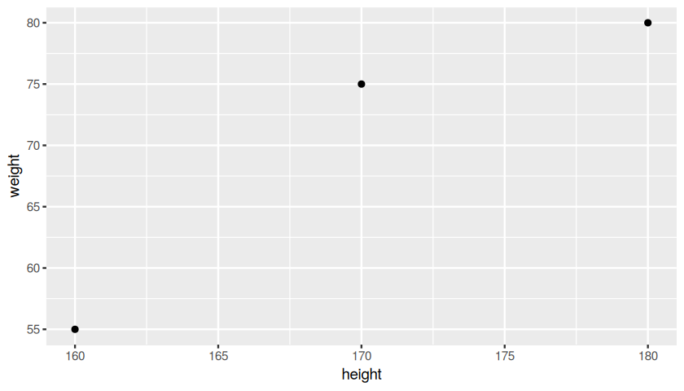

```r
options(repr.plot.width = 7, repr.plot.height = 4)
ggplot(data = tbp) + geom_point(aes(x = height, y = weight))
```

### `geom_line()`

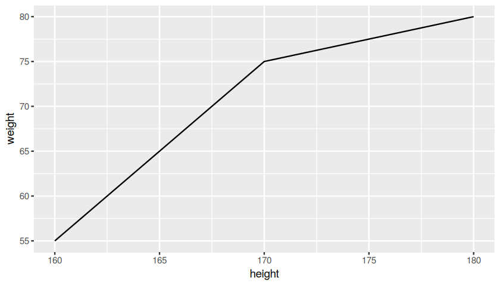

```r
ggplot(data = tbp) + geom_line(aes(x = height, y = weight))
```

### Combining layers and mapping a colour

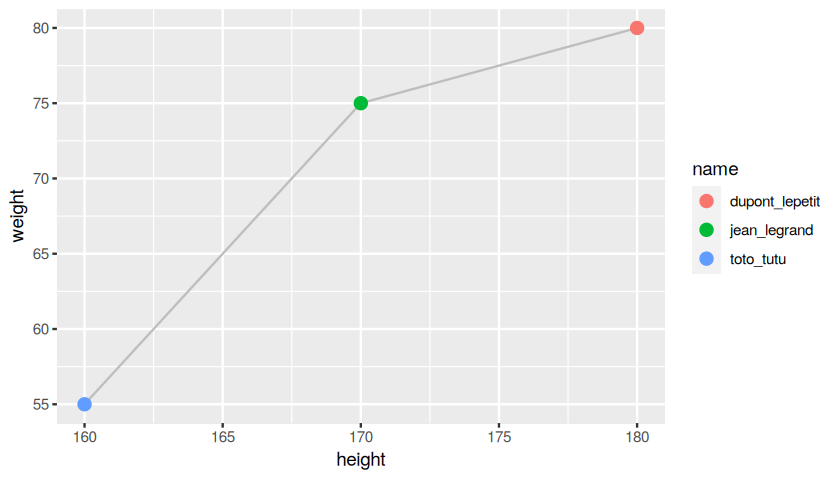

```r
ggplot(data = tbp) +
  geom_line(aes(x = height, y = weight), color = "grey") +
  geom_point(aes(x = height, y = weight, color = name), size = 3)
```

ℹ️ **Note**  
`color = "grey"` **outside** `aes()` sets a constant. `color = name` **inside** `aes()` maps a variable to the colour.

### Distributions: `geom_histogram()` and `geom_density()`

Simulated depth for two samples, with a minimum-depth threshold (`geom_vline()`).

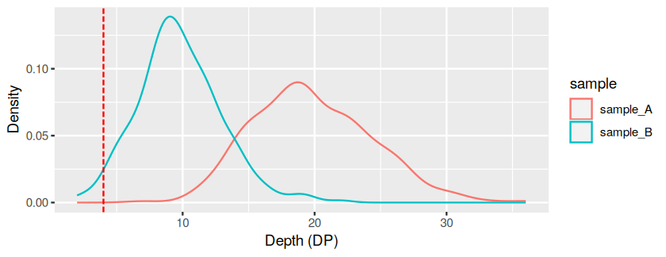

```r
options(repr.plot.width = 7, repr.plot.height = 2.7)
set.seed(42)
depth <- tibble(sample = rep(c("sample_A", "sample_B"), each = 300),
                DP     = c(rpois(300, lambda = 20), rpois(300, lambda = 10)))

ggplot(depth, aes(x = DP, color = sample)) +
  geom_density() +
  geom_vline(xintercept = 4, color = "red", linetype = "longdash") +
  labs(x = "Depth (DP)", y = "Density")
```

### Histogram

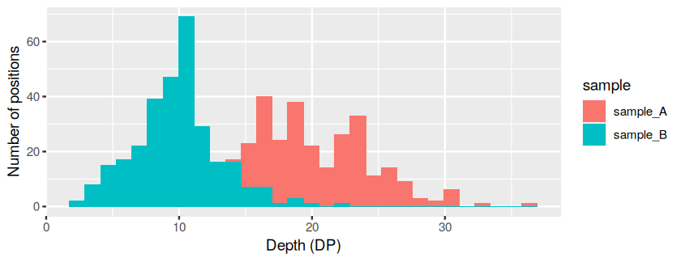

```r
ggplot(depth, aes(x = DP, fill = sample)) +
  geom_histogram(bins = 30, position = "identity") +
  labs(x = "Depth (DP)", y = "Number of positions")
```

## VII - Exercises

❓ **Question**  
Using the tibble `depth` defined above:  
1. How many positions have `DP < 4` in each sample?  
2. Compute the mean and the median depth per sample.  
3. Add a column `low_cov` equal to `"low"` if `DP < 10`, else `"ok"`, then count the rows per sample and per class.

❓ **Question**  
Using the vector `alt <- c("A", "AT", "C,T", "G", "TCC")`:  
build a tibble with the columns `alt`, `n_alleles` (1 + number of commas) and `type` (`"SNV"` if the length is 1 and there is no comma, `"multi-allelic"` if there is a comma, otherwise `"INDEL"`).

## Summary

- **Tidy data**: one variable per column, one observation per row, one value per cell; `tibble` is the table format.
- **`tidyr`**: `unite` / `separate` to merge or split columns, `pivot_longer` / `pivot_wider` to change the shape.
- **`dplyr`**: `filter` (rows), `select` (columns), `mutate` (new columns, with `if_else` / `case_when`), `group_by` + `summarise` / `count`, and the `*_join` family.
- **`stringr`**: `str_detect`, `str_length`, `str_extract`, `str_remove` to handle text fields such as ALT or ANN.
- **`ggplot2`**: data + `aes()` + `geom_*()`, layers added with `+`.
- Chain the steps with the pipe `%>%`.

**Next**: the same tools applied to a VCF file (notebook *05_Manipulating_VCF_post_calling*).